# Olympic Data

## 9.2 Number of Olympic Athletes

Looking at the same countries, the plot shows the number of athletes they sent to the Olympics from 1908 - 1928.

[figure not shown]

Great Britain and Sweden saw a sharp decline in the number of athletes that they sent to Olympic events after the pandemic. JOHNSON, NIALL P. A. S., and JUERGEN MUELLER reported England & Wales had approximately 200,000 death toll (per 1,000) and Sweden reported 34,374 death toll during the 1918-1919 pandemic.

## 9.3 Average Age of Olympians

The chart displays the average age of Olympians from the eight countries in our data before and after the pandemic.

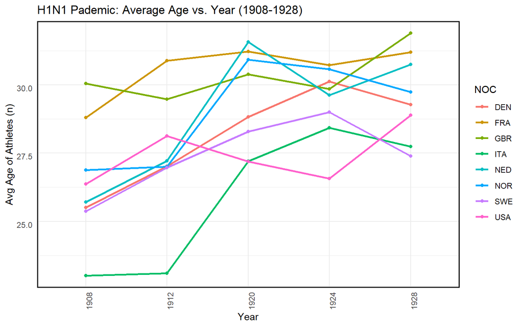

## 9.4 Average Height and Weight of Olympians

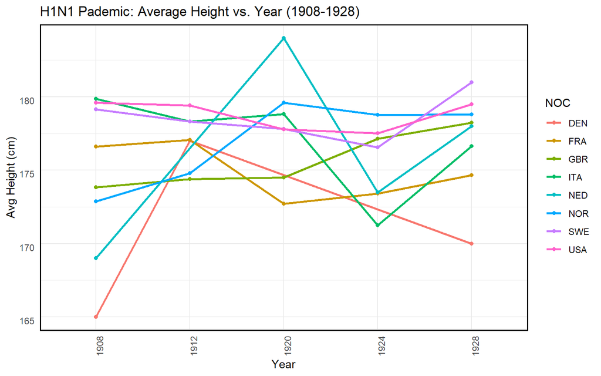

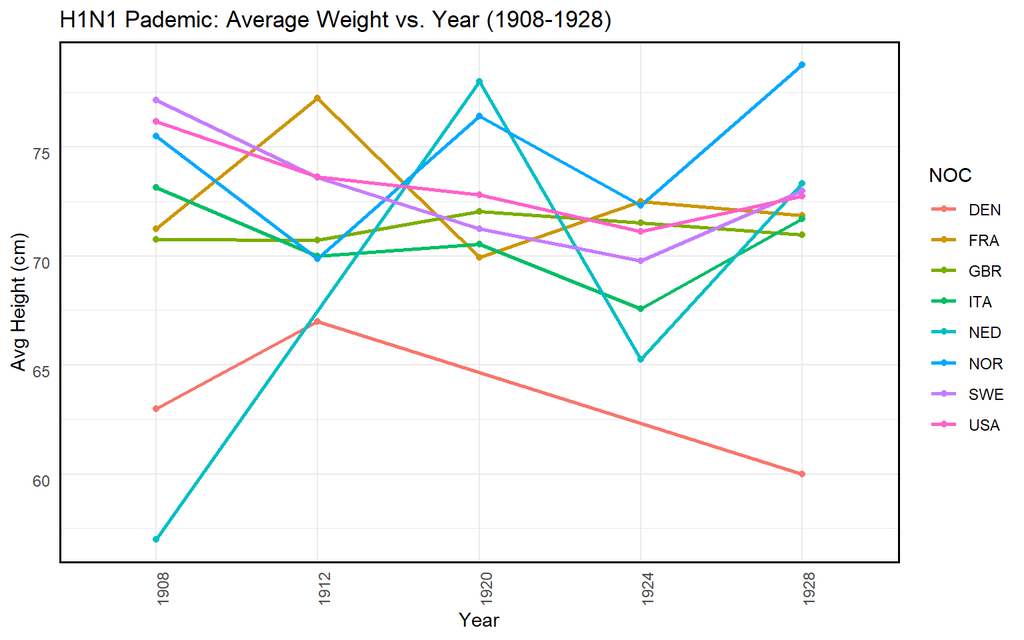

Netherlands (NED) and Norway (NOR) had significant increase in the average height and weight of their athletes after Spanish flu pandemic. Sweden (SWE) and France (FRA) saw a decrease in those averages.

## 9.5 Total Number of Olympic Medals (Summer Events) vs. Year

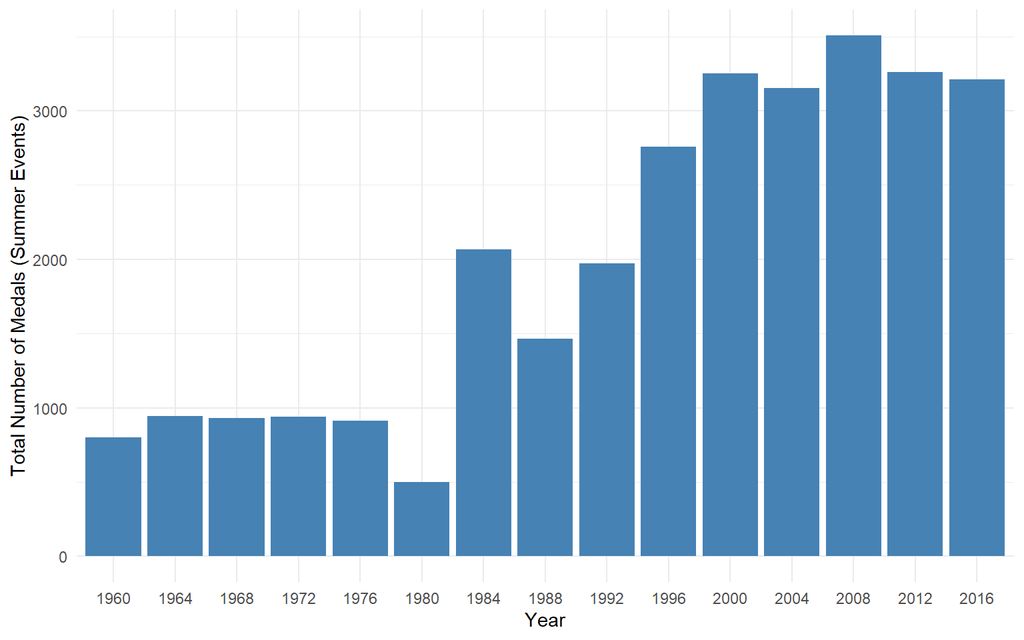

## 9.6 Creating Time Series - Italy

During the 1918 Pandemic, Italy’s death toll (per 1,000) was 390,000 death toll. According to [Worldodometer](https://www.worldometers.info/coronavirus/country/italy/), during the current Covid-19 pandemic, there has been 29,079 deaths in Italy. We will focus on Italy to conduct time series analysis. Can we see a pattern with historical Olympic data before and after the Spanish flu in order to predict how Italy will fare in future Olympics after is emerges from the current novel Corona virus pandemic?

[figure not shown]

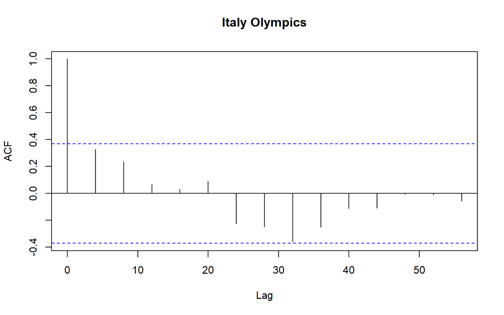

## 9.7 Using 1908-1928 Time Series as Training Data

From the quick EDA, time series may not be appropriate method to model the number of medals Italy may earn in future Olympics. As a learning academic exercise, we will explore different time series methodologies to forecast.

## 9.8 Exploring Holt-Winters and ETS-ANN Time Series Forecasting

Holt-Winters uses exponential smoothing to make short-term forecasts. Models is designated as either additive or multiplicative.

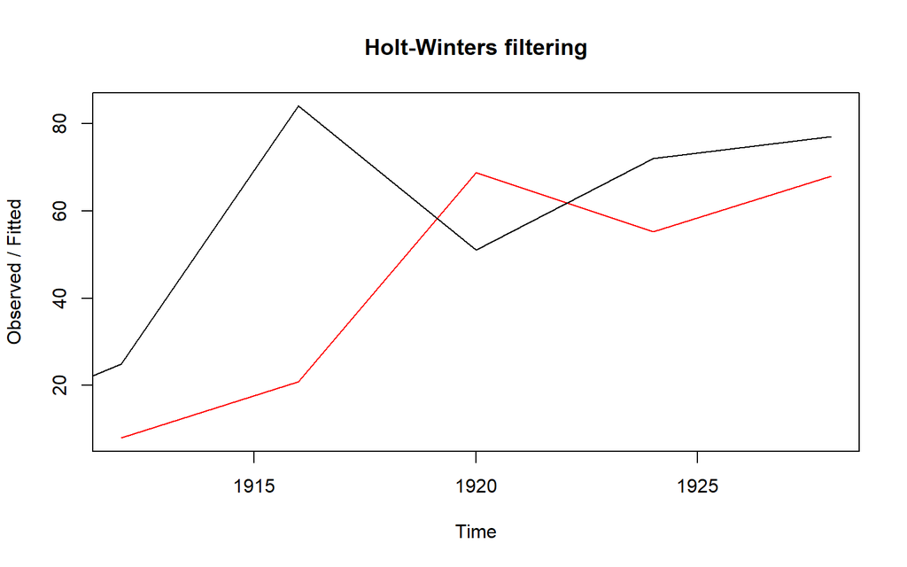

[output not shown]

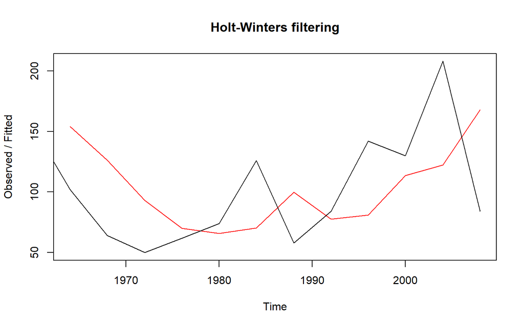

```
     Point Forecast    Lo 80    Hi 80    Lo 95    Hi 95
2012       102.9043 40.58979 165.2189 7.602475 198.2062
2016       102.9043 40.58979 165.2189 7.602475 198.2062
2020       102.9043 40.58979 165.2189 7.602474 198.2062
```

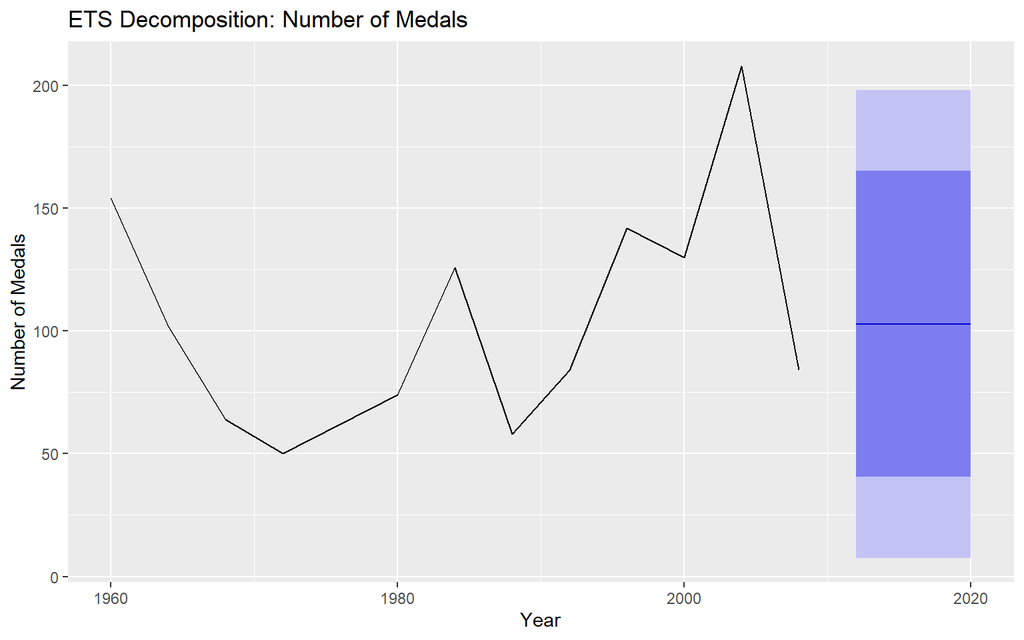

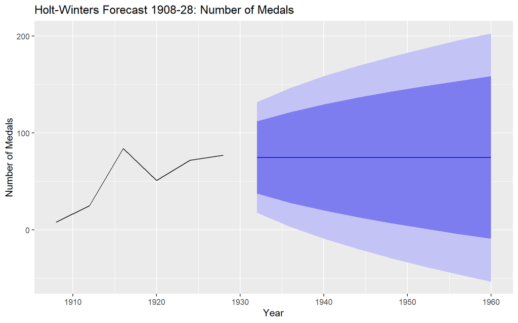

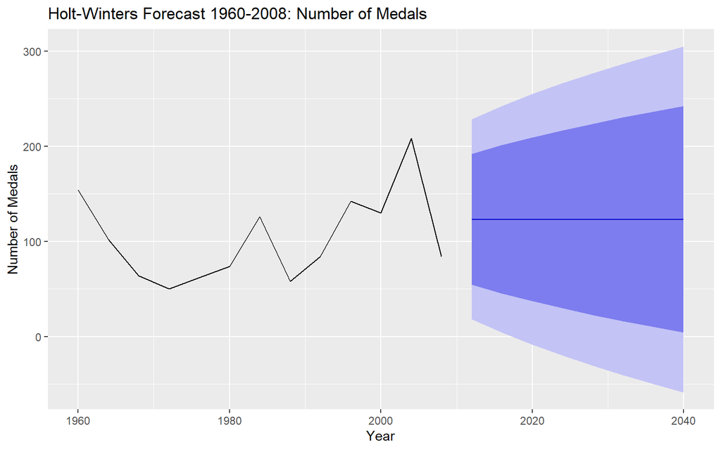